# Group Project Analysis Final report

### Tabulation of various categorical columns with hour column

```r
bh <- table(df_Daksh$hour, df_Daksh$Belts)
bh
```

```
##
##         No   Yes
##   1  19125   300
##   2  15769   270
##   3  11936   200
##   4   8108   148
##   5   4959   103
##   6   3036   127
##   7   4995   238
##   8  11711   624
##   9  17297   972
##   10 16164   902
##   11 16413   873
##   12 13897   800
##   13 12502   604
##   14 12930   655
##   15 13527   700
##   16 11704   576
##   17 16217   558
##   18 16960   514
##   19 13347   381
##   20 11968   379
##   21 13329   355
##   22 19152   414
##   23 26811   499
##   24 26300   429
```

- **View of people reported for violation of Belts on hourly basis.**

```r
ah <- table(df_Daksh$hour, df_Daksh$Alcohol)
ah
```

```
##
##         No   Yes
##   1  19407    18
##   2  16023    16
##   3  12119    17
##   4   8226    30
##   5   5049    13
##   6   3161     2
##   7   5221    12
##   8  12297    38
##   9  18222    47
##   10 17033    33
##   11 17268    18
##   12 14683    14
##   13 13095    11
##   14 13560    25
##   15 14202    25
##   16 12254    26
##   17 16737    38
##   18 17411    63
##   19 13667    61
##   20 12310    37
##   21 13669    15
##   22 19564     2
##   23 27298    12
##   24 26720     9
```

- **View of people reported for violation of Alcohol on hourly basis.**

```r
hh <- table(df_Daksh$hour, df_Daksh$HAZMAT)
hh
```

```
##
##         No   Yes
##   1  19424     1
##   2  16039     0
##   3  12136     0
##   4   8256     0
##   5   5062     0
##   6   3163     0
##   7   5233     0
##   8  12333     2
##   9  18263     6
##   10 17065     1
##   11 17282     4
##   12 14695     2
##   13 13105     1
##   14 13583     2
##   15 14227     0
##   16 12280     0
##   17 16773     2
##   18 17474     0
##   19 13728     0
##   20 12346     1
##   21 13684     0
##   22 19566     0
##   23 27310     0
##   24 26729     0
```

- **View of people reported for violation of Harzardious Materials on hourly basis.**

```r
hf <- table(df_Daksh$hour, df_Daksh$Fatal)
hf
```

```
##
##         No   Yes
##   1  19423     2
##   2  16037     2
##   3  12135     1
##   4   8255     1
##   5   5057     5
##   6   3160     3
##   7   5231     2
##   8  12333     2
##   9  18267     2
##   10 17063     3
##   11 17279     7
##   12 14695     2
##   13 13101     5
##   14 13583     2
##   15 14224     3
##   16 12278     2
##   17 16759    16
##   18 17470     4
##   19 13726     2
##   20 12347     0
##   21 13682     2
##   22 19561     5
##   23 27309     1
##   24 26726     3
```

```r
#Getting the violation recorded by each subagency on yearly basis
#sy <- table(df_Daksh$year, df_Daksh$SubAgency)
#sy

#Getting the violation recorded based on quaters
#qv <- table(df_Daksh$Quaterly_view2, df_Daksh$year)
#qv
```

- **View of Fatalities reported after violation on hourly basis.**

### Data encoding for Heatmap

```r
df_Daksh <- df_Daksh %>%
  mutate(belten = if_else(Belts == "No", 0, 1)) %>%
  mutate(alcoholn = if_else(Alcohol == "No", 0, 1))%>%
  mutate(hazmatn = if_else(HAZMAT == "No", 0,1))%>%
  mutate(personinjuryn = if_else(Personal.Injury == "No", 0, 1))%>%
  mutate(propdamn = if_else(Property.Damage == "No", 0, 1))%>%
  mutate(fataln = if_else(Fatal == "No", 0, 1))%>%
  mutate(workzonen = if_else(Work.Zone == "No", 0, 1))%>%
  mutate(genn = if_else(Gender == "F", 0, 1)) %>%
  mutate(violation_y = if_else(Belts == "Yes" | Commercial.License == "Yes"
                               | Alcohol == "Yes" | HAZMAT == "Yes", "Yes", "No"))

df_Daksh <- df_Daksh %>%
  mutate(Day_view = case_when(hour <=5 ~ "Midnight",
                              (hour >5 & hour <=11) ~ "Morning",
                              (hour>11 & hour <=16)  ~ "Afternoon",
                              (hour > 16 & hour <= 20) ~ "Evening",
                               hour >20 ~ "Night"))
df_Daksh <- df_Daksh %>%
  mutate(Dayn = case_when(Day_view == "Midnight" ~ 0,
                          Day_view == "Morning" ~ 1,
                          Day_view == "Afternoon" ~ 2,
                          Day_view == "Evening" ~ 3,
                          Day_view == "Night" ~ 4))


df_Daksh$subagencyn <-  as.numeric(factor(df_Daksh$SubAgency,levels = c("1st district, Rockville", " 2nd district, Bethesda","3rd district, Silver Spring","4th district, Wheaton","5th district, Germantown","6th district, Gaithersburg / Montgomery Village",
                                                                        "Headquarters and Special Operations"),
labels =c("1","2","3","4","5","6","7"),ordered = TRUE))
```

### Heat Map to understand the correlation.

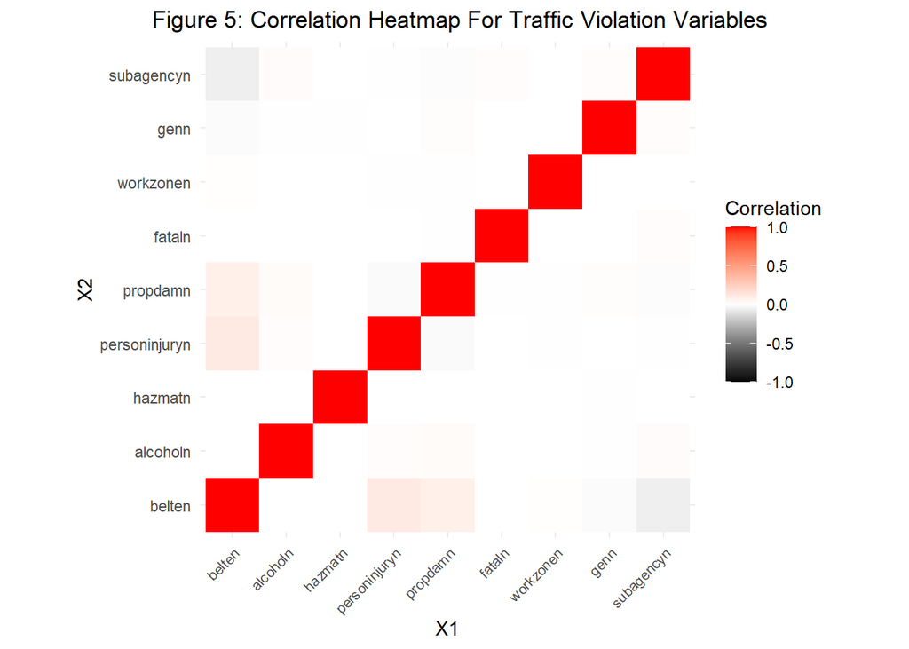

```r
heat_violation <- c("belten","alcoholn","hazmatn","personinjuryn","propdamn","fataln","workzonen","genn", "subagencyn")
heat_plot <- df_Daksh[,heat_violation]

#plot correlation heatmap for understainding the relation between various columns
qplot(x=X1, y=X2, data=melt(cor(heat_plot, use="p")), fill=value, geom="tile") +
   scale_fill_gradient2(low = "black", high = "red", mid = "white",
   midpoint = 0, limit = c(-1,1), space = "Lab",
   name="Correlation") +
   theme_minimal()+
   theme(axis.text.x = element_text(angle = 45, vjust = 1, size = 8, hjust = 1))+
   coord_fixed()+
   ggtitle("Figure 5: Correlation Heatmap For Traffic Violation Variables") +
   theme(plot.title = element_text(hjust = 0.4))
```

- According to the heat map above, there is a very weak association between those who violate the law by not wearing seat belts and personal injury, with no other correlation between other variables plotted in the heat map.

### Chi-square test of independce

- We will check if the relation of various categorical columns with other categorical columns
- H0 = The variable Gender and Violation Type are Independent.
- H1 = The variable Gender and Violation Type are Dependent.

```r
chi1 <- xtabs(~ Gender + Violation.Type, data = df_Daksh)
chi1
```

```
##       Violation.Type
## Gender Citation  ESERO   SERO Warning
##      F    50582   5364     48   57877
##      M   122240  12323    103  100883
##      U       59      4      0     295
```

```r
chisq.test(chi1)
```

```
##
##  Pearson's Chi-squared test
##
## data:  chi1
## X-squared = 2186.3, df = 6, p-value < 2.2e-16
```

- From the above observation we understand that the Gender and Violation type have some dependence.
- H0 = The variable Race and Violation Type are Independent.
- H1 = The variable Race and Violation Type are Dependent.

```r
chi2 <- xtabs(~ Race + Violation.Type, data = df_Daksh)
chi2
```

```
##                  Violation.Type
## Race              Citation ESERO  SERO Warning
##   ASIAN               8362  1161    12   10693
##   BLACK              56484  5449    44   49677
##   HISPANIC           42023  4971    46   29068
##   NATIVE AMERICAN      336    50     0     401
##   OTHER               8148   832    10    9933
##   WHITE              57528  5228    39   59283
```

```r
chisq.test(chi2)
```

```
##
##  Pearson's Chi-squared test
##
## data:  chi2
## X-squared = 3254.9, df = 15, p-value < 2.2e-16
```

- From the above observation we understand that the Race and Violation type have some dependence.

### ANOVA Analysis for variance.

- The ANOVA analysis cannot be performed since we do not have any continuous quantitative variable in our observation.

### Data Preparation for Logistics Model.

```r
df_Daksh <- df_Daksh %>%
  mutate(Quaterly_view2 = case_when(month_code <=3 ~ 1,
                              (month_code >3 & month_code <=6) ~ 2,
                              (month_code>6 & month_code <=9)  ~ 3,
                              (month_code > 9 & month_code <= 12) ~ 4))

df_Daksh$cartype <-  as.numeric(factor(df_Daksh$VehicleType,levels = c("01 - Motorcycle", "02 - Automobile","03 - Station Wagon","04 - Limousine",
"05 - Light Duty Truck", "06 - Heavy Duty Truck","07 - Truck/Road Tractor", "08 - Recreational Vehicle",  "09 - Farm Vehicle", "10 - Transit Bus",
"11 - Cross Country Bus","12 - School Bus","13 - Ambulance","13 - Ambulance(Emerg)","14 - Ambulance",
"14 - Ambulance(Non-Emerg)","15 - Fire Vehicle","15 - Fire(Emerg)","16 - Fire(Non-Emerg)","17 - Police(Emerg)",
"18 - Police Vehicle","18 - Police(Non-Emerg)","19 - Moped","20 - Commercial Rig","21 - Tandem Trailer",
"22 - Mobile Home","23 - Travel/Home Trailer","24 - Camper","25 - Utility Trailer","26 - Boat Trailer",
"27 - Farm Equipment","28 - Other","29 - Unknown"),
labels =c("1","2","3","3","4","4","4","5","5","6","6","6","7","7","7","7","7","7","7","7","7","7","1","5","8","8","8","8","8","8","5","5","5"),ordered = TRUE))

#df_Daksh <- df_Daksh %>% drop_na()
```

- Reducing the Vehicle type to generalized for car type
- Encoding month code to quarter basis

### Logistics model

#### Model 1

```r
m1 <- glm(belten ~ Gender + Race + workzonen + cartype + SubAgency + Commercial.Vehicle + Quaterly_view2 , data = train, family = binomial(link = "logit"))

summary(m1)
```

```
##
## Call:
## glm(formula = belten ~ Gender + Race + workzonen + cartype +
##     SubAgency + Commercial.Vehicle + Quaterly_view2, family = binomial(link = "logit"),
##     data = train)
##
## Deviance Residuals:
##     Min       1Q   Median       3Q      Max
## -0.8798  -0.3159  -0.2204  -0.1904   3.8533
##
## Coefficients:
##                                                           Estimate Std. Error
## (Intercept)                                              -3.110474   0.066193
## GenderM                                                  -0.145149   0.024179
## GenderU                                                  -1.549100   0.583540
## RaceBLACK                                                -0.099683   0.052204
## RaceHISPANIC                                              0.037356   0.053567
## RaceNATIVE AMERICAN                                      -0.480106   0.323924
## RaceOTHER                                                 0.151548   0.066652
## RaceWHITE                                                 0.126442   0.050887
## workzonen                                                 1.816437   0.416380
## cartype                                                   0.180518   0.013479
## SubAgency2nd district, Bethesda                          -1.243959   0.045199
## SubAgency3rd district, Silver Spring                     -0.210184   0.034149
## SubAgency4th district, Wheaton                           -0.967587   0.036846
## SubAgency5th district, Germantown                        -3.262156   0.122257
## SubAgency6th district, Gaithersburg / Montgomery Village -0.075613   0.035461
## SubAgencyHeadquarters and Special Operations             -3.156144   0.210372
## Commercial.VehicleYes                                    -0.899524   0.282835
## Quaterly_view2                                            0.005437   0.010172
##                                                          z value Pr(>|z|)
## (Intercept)                                              -46.991  < 2e-16 ***
## GenderM                                                   -6.003 1.93e-09 ***
## GenderU                                                   -2.655  0.00794 **
## RaceBLACK                                                 -1.909  0.05620 .
## RaceHISPANIC                                               0.697  0.48557
## RaceNATIVE AMERICAN                                       -1.482  0.13830
## RaceOTHER                                                  2.274  0.02298 *
## RaceWHITE                                                  2.485  0.01296 *
## workzonen                                                  4.362 1.29e-05 ***
## cartype                                                   13.393  < 2e-16 ***
## SubAgency2nd district, Bethesda                          -27.522  < 2e-16 ***
## SubAgency3rd district, Silver Spring                      -6.155 7.51e-10 ***
## SubAgency4th district, Wheaton                           -26.260  < 2e-16 ***
## SubAgency5th district, Germantown                        -26.683  < 2e-16 ***
## SubAgency6th district, Gaithersburg / Montgomery Village  -2.132  0.03299 *
## SubAgencyHeadquarters and Special Operations             -15.003  < 2e-16 ***
## Commercial.VehicleYes                                     -3.180  0.00147 **
## Quaterly_view2                                             0.535  0.59299
## ---
## Signif. codes:  0 '***' 0.001 '**' 0.01 '*' 0.05 '.' 0.1 ' ' 1
##
## (Dispersion parameter for binomial family taken to be 1)
##
##     Null deviance: 70536  on 244845  degrees of freedom
## Residual deviance: 66708  on 244828  degrees of freedom
## AIC: 66744
##
## Number of Fisher Scoring iterations: 8
```